# Homework 06

## Question 1: Compare KNN and logistic regression

Use breast-cancer.csv, which contains 569 cases from the [Wisconsin Diagnostic Breast Cancer dataset](https://archive.ics.uci.edu/dataset/17/breast%2Bcancer%2Bwisconsin%2Bdiagnostic). Predict `y` (1 for malignant and 0 for benign) using `mean_radius`, `mean_texture`, and `mean_smoothness`.

Set a random seed and randomly split the observations into 70% training and 30% test data. Use the same split for every model. Standardize the predictors using the training means and standard deviations, and apply the same transformations to the test data.

Fit ordinary logistic regression with an intercept and no penalty, and KNN with Euclidean distance, equal neighbor weights, and

$$k\in\{5,15,25,35,45\}.$$

Using the estimated probabilities for `y = 1` on the test data, plot all six ROC curves in one figure and report their AUC values. Which of the six fitted models do you prefer? Give a brief justification based on your results.

**Show the workflow**

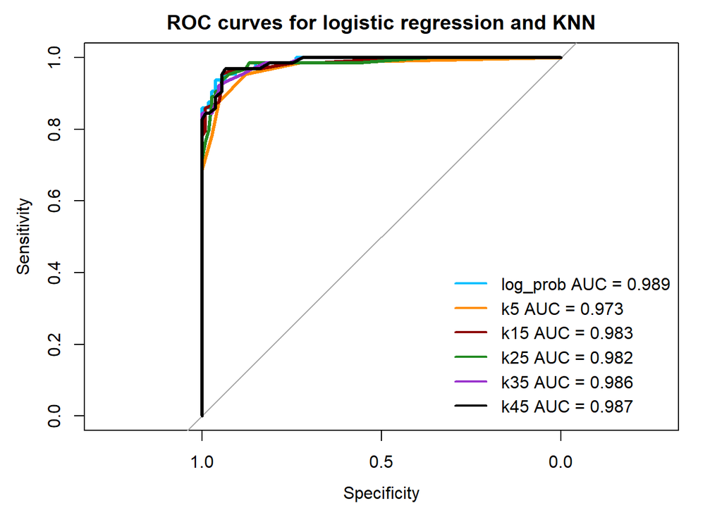

```r
set.seed(43201)

# Read .csv file and randomly split observations into 70% training and 30% test data
# Source: https://www.geeksforgeeks.org/r-language/split-the-dataset-into-the-training-test-set-in-r/
df_breast_cancer <- read.csv("data/breast-cancer.csv")

n <- nrow(df_breast_cancer)
sample_index <- sample(seq_len(n), size = floor(0.70 * n))

train <- df_breast_cancer[sample_index, ]
test <- df_breast_cancer[-sample_index, ]

# Standardize the predictors using training means and standard deviations
predictors <- c("mean_radius", "mean_texture", "mean_smoothness")

train_mean <- colMeans(train[predictors])
train_sd <- sapply(train[predictors], sd)

X_train <- train
X_train[predictors] <- scale(train[predictors],
                             center = train_mean,
                             scale = train_sd)
y_train <- train$y

# Apply the same transformations to the test data
X_test <- test
X_test[predictors] <- scale(test[predictors],
                            center = train_mean,
                            scale = train_sd)
y_test <- test$y

# Fit ordinary logistic regression w/ an intercept and no penalty
# Source: https://teazrq.github.io/stat432rpy/topics/classification-evaluation/classification-model-evaluation.html
log_fit <- glm(y ~ ., data = X_train, family = binomial())
log_prob <- predict(log_fit, newdata = X_test, type = "response")

# Fit KNN with Euclidean distance, equal neighbor weights, and k_values
# Source: https://teazrq.github.io/stat432rpy/topics/nearest-neighbors/knn-and-local-averaging.html
library(kknn)

k_values <- seq(from = 5, to = 45, by = 10)
knn_probs <- list()

for (i in seq_along(k_values)){
  knn_fit <- kknn(y ~ ., train = X_train, test = X_test,
                  k = k_values[i], kernel = "rectangular")

  knn_probs[[i]] <- as.vector(fitted(knn_fit))
}

# Convert knn_probs from list to a dataframe for readability
df_knn_probs <- as.data.frame(knn_probs)
names(df_knn_probs) <- paste0("k", k_values)

# Combine knn_probs and log_prob
df_knn_log_probs <- cbind(log_prob, df_knn_probs)

# Use estimated probabilities for y = 1 on test data
library(pROC)

roc_list <- list()
auc_values <- c()

for (m in names(df_knn_log_probs)){
  roc_list[[m]] <- roc(y_test, df_knn_log_probs[[m]], quiet = TRUE)
  auc_values[[m]] <- auc(roc_list[[m]])
}

# Plot all six ROC curves in one figure
plot(roc_list[[1]], type = "l", col = "deepskyblue", lwd = 3,
     main = "ROC curves for logistic regression and KNN")
lines(roc_list[[2]], type = "l", col = "darkorange", lwd = 3)
lines(roc_list[[3]], type = "l", col = "darkred", lwd = 3)
lines(roc_list[[4]], type = "l", col = "forestgreen", lwd = 3)
lines(roc_list[[5]], type = "l", col = "darkorchid", lwd = 3)
lines(roc_list[[6]], type = "l", col = "black", lwd = 3)

legend("bottomright",
       legend = paste(names(roc_list), sprintf("AUC = %.3f", auc_values)),
       col = c("deepskyblue", "darkorange",
               "darkred", "forestgreen",
               "darkorchid", "black"),
       lwd = 2,
       bty = "n"
       )
```

**Show the workflow**

```r
auc_values
```

```
$log_prob
Area under the curve: 0.9888

$k5
Area under the curve: 0.9725

$k15
Area under the curve: 0.9834

$k25
Area under the curve: 0.9821

$k35
Area under the curve: 0.9861

$k45
Area under the curve: 0.9871
```

From Week 6 Lecture: Evaluating Classification Models, “[t]he area under the ROC curve, or AUC, summarizes how well the fitted probabilities rank the two classes. It ranges from zero to one.” I prefer the logistic regression model because it has the highest test AUC of 0.989. The logistic regression AUC is very close to 1, which means “almost every positive case is ranked above every negative case”.

## Question 2: Training and test ROC curves

Use the same data, training/test split, and standardization as in Question 1. Fit KNN with Euclidean distance, equal neighbor weights, and

$$k\in\{1,3,5,10,20\}.$$

Use each fitted model to estimate probabilities for both the training and test observations. For training predictions, include each observation itself among its $k$ nearest neighbors.

For each $k$, use a separate panel to show the training and test ROC curves together. Report both AUC values.

Explain the difference between training and test performance and how it changes with $k$. In particular, explain what happens at $k=1$ and why training performance may not reflect performance on new observations.

**Show the workflow**

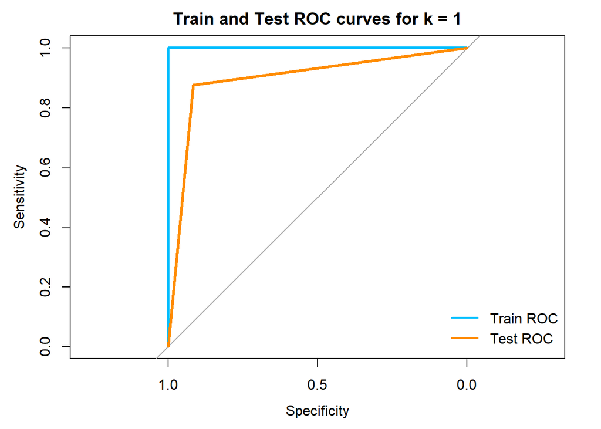

```r
# Fit KNN with Euclidean distance, equal neighbor weights, and k_values2
k_values2 <- c(1, 3, 5, 10, 20)

train_probs <- list()
test_probs <- list()

roc_train <- list()
roc_test <- list()

auc_train <- c()
auc_test <- c()

for (i in seq_along(k_values2)){
  knn_fit_train <- kknn(y ~ ., train = X_train, test = X_train,
                  k = k_values2[i], kernel = "rectangular")

  knn_fit_test <- kknn(y ~ ., train = X_train, test = X_test,
                        k = k_values2[i], kernel = "rectangular")

  # Use each fitted model to estimate probailities for both the training and test observations
  train_probs <- as.vector(fitted(knn_fit_train))
  test_probs <- as.vector(fitted(knn_fit_test))

  # For each k, compute ROC and AUC values
  roc_train[[i]] <- roc(y_train, train_probs, quiet = TRUE)
  roc_test[[i]] <- roc(y_test, test_probs, quiet = TRUE)

  auc_train[i] <- auc(roc_train[[i]])
  auc_test[i] <- auc(roc_test[[i]])

}

# For each k, use a separate panel to show the training and test ROC curves together. Report both AUC values.
# k = 1
plot(roc_train[[1]], type = "l", col = "deepskyblue", lwd = 3,
     main = "Train and Test ROC curves for k = 1")
lines(roc_test[[1]], type = "l", col = "darkorange", lwd = 3)
legend("bottomright",
       legend = c("Train ROC", "Test ROC"),
       col = c("deepskyblue", "darkorange"),
       lwd = 2,
       bty = "n"
)
```

**Show the workflow**

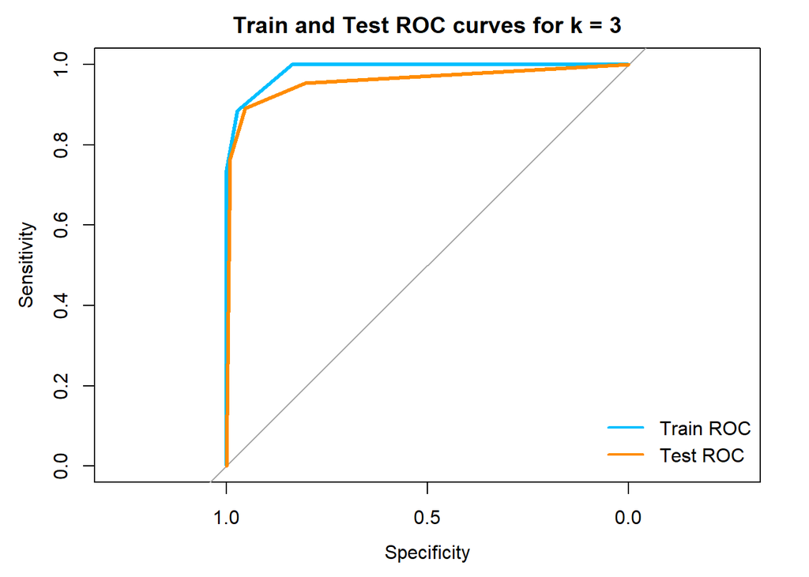

```r
# k = 3
plot(roc_train[[2]], type = "l", col = "deepskyblue", lwd = 3,
     main = "Train and Test ROC curves for k = 3")
lines(roc_test[[2]], type = "l", col = "darkorange", lwd = 3)
legend("bottomright",
       legend = c("Train ROC", "Test ROC"),
       col = c("deepskyblue", "darkorange"),
       lwd = 2,
       bty = "n"
)
```

**Show the workflow**

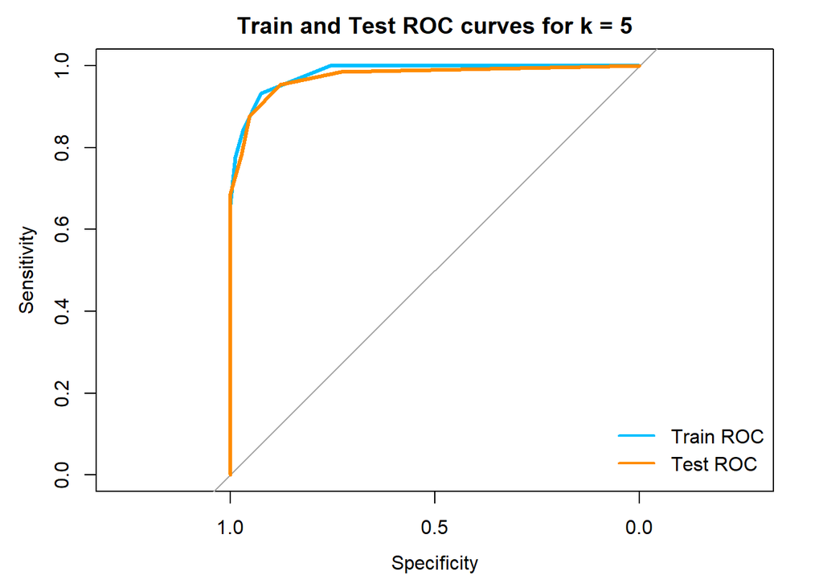

```r
# k = 5
plot(roc_train[[3]], type = "l", col = "deepskyblue", lwd = 3,
     main = "Train and Test ROC curves for k = 5")
lines(roc_test[[3]], type = "l", col = "darkorange", lwd = 3)
legend("bottomright",
       legend = c("Train ROC", "Test ROC"),
       col = c("deepskyblue", "darkorange"),
       lwd = 2,
       bty = "n"
)
```

**Show the workflow**

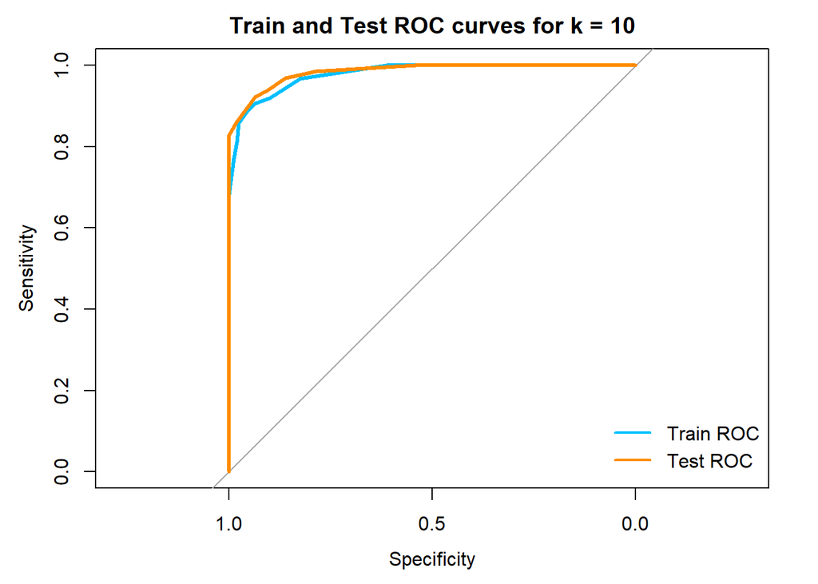

```r
# k = 10
plot(roc_train[[4]], type = "l", col = "deepskyblue", lwd = 3,
     main = "Train and Test ROC curves for k = 10")
lines(roc_test[[4]], type = "l", col = "darkorange", lwd = 3)
legend("bottomright",
       legend = c("Train ROC", "Test ROC"),
       col = c("deepskyblue", "darkorange"),
       lwd = 2,
       bty = "n"
)
```

**Show the workflow**

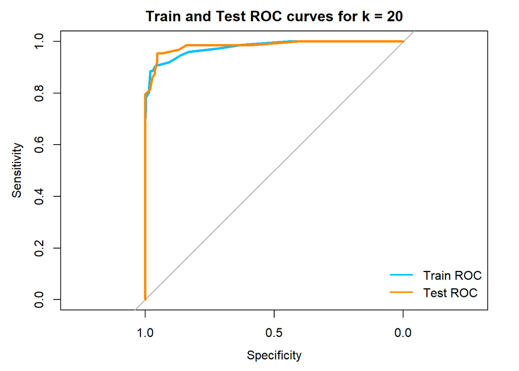

```r
# k = 20
plot(roc_train[[5]], type = "l", col = "deepskyblue", lwd = 3,
     main = "Train and Test ROC curves for k = 20")
lines(roc_test[[5]], type = "l", col = "darkorange", lwd = 3)
legend("bottomright",
       legend = c("Train ROC", "Test ROC"),
       col = c("deepskyblue", "darkorange"),
       lwd = 2,
       bty = "n"
)
```

**Show the workflow**

```r
# Report AUC values
auc_results <- data.frame(
  k = k_values2,
  auc_train = auc_train,
  auc_test = auc_test
)
auc_results
```

```
   k auc_train  auc_test
1  1 1.0000000 0.8954439
2  3 0.9868919 0.9572868
3  5 0.9822703 0.9725467
4 10 0.9786081 0.9841560
5 20 0.9776892 0.9833528
```

At k = 1, the KNN model relies on the closest data point, which makes the model very flexible. The training AUC value is 1 (i.e., a perfect ROC curve), but the testing AUC value is less than 1 due to noisy predictions. In other words, the model overfits on the training data and does not perform well on the testing data.

## Question 3: Peer evaluation of Homework 5

You will receive two Homework 5 submissions to review. The instructor’s GitHub account, **rqzhu-aide**, will open a **GitHub Issue** in the repository containing your Homework 5 submission. It will contain links to two other students’ repositories, where you can find their submitted homework reports.

Open your repository’s **Issues** tab on GitHub to find the assignment. You may ask AI to explain GitHub Issues or help you locate the assignment.

Choose **one specific mistake or item for improvement** from any question in either report.

1. **Identify the mistake or item for improvement.** State which report and question you selected, and briefly describe what is wrong or could be improved. Examples include incorrect code, a calculation error, a misinterpretation of results, a plot that could communicate the findings more clearly, or anything else you think could be done better.
2. **Explain your assessment.** Quote the relevant text, code, or figure caption exactly. Explain why the selected answer is incorrect or how it could be improved, referring to its reasoning, calculations, code, figures, or interpretation. **Complete this part yourself, without AI assistance.**
3. **Provide a correction.** Write a corrected or improved answer to the selected question, including any calculations, code, or figures needed.

After completing your review, **open a GitHub Issue in the repository containing the report you selected**. Identify the report and question, and include your assessment and a detailed revision plan explaining what the author should change and why. Include a link to your posted GitHub Issue in your Homework 6 answer.